# Coursework Report

*N* removed NAs: 3

*N* removed typo: 1

*N* removed <18: 17

*N* total clean: 129

| Group | *N* | *M*<sub>age</sub> | *M*<sub>rating</sub> |
| --- | --- | --- | --- |
| Control | 63 | 21.1 | 6.74 |
| Experim | 66 | 20.7 | 6.07 |

**Main analysis results**

*t*(127) = 4.42, *p* < .001

[interactive chart not shown]

[figure not shown]

[interactive chart not shown]

# Coursework Report

Analysing Data, Spring 2020

# Methods

## Participants

Table 1 *Descriptive statistics by experimental condition*

| Condition | *N* | *M*<sub>age</sub> | *SD*<sub>age</sub> |
| --- | --- | --- | --- |
| White | 63 | 21.1 | 1.94 |
| Red | 66 | 20.7 | 1.94 |

## Design

This experiment investigates the influence of the colour red in woman’s perceived attractiveness of a man, compared to white due to its unobtrusive neutral quality. In this experiment, colour is the independent categorical variable, with 2 levels: red (experimental condition) and white (control condition). Attractiveness is the continuous variable, measured on a 1-9 scale where a higher score indicates more attractiveness. Participants viewed a greyscale photograph of a man on a red or white background for 5s, then rated the photograph for perceived attractiveness of the man. The photograph was a standard 6”x4” headshot (including upper torso) of a moderately attractive white male with brunette hair wearing a plain shirt. The red frame was placed in the area surrounding the man, while white was simply the absence of colour in the surrounding frame. Perceived attraction was measured through 3 questions: “How attractive do you think this person is?”, “How pleasant is this person to look at?”, and “If I were to meet the person in this picture face to face, I would think he is attractive.” These items were rated on a scale ranging from 1 (*not at all attractive*) - 9 (*extremely attractive*), and the 3 items were averaged to provide a composite index.This study tests whether manipulating different colour frames behind a photo of a moderately attractive man will affect mean ratings of his attractiveness. Results will be analysed using the *t*-test.

# Results

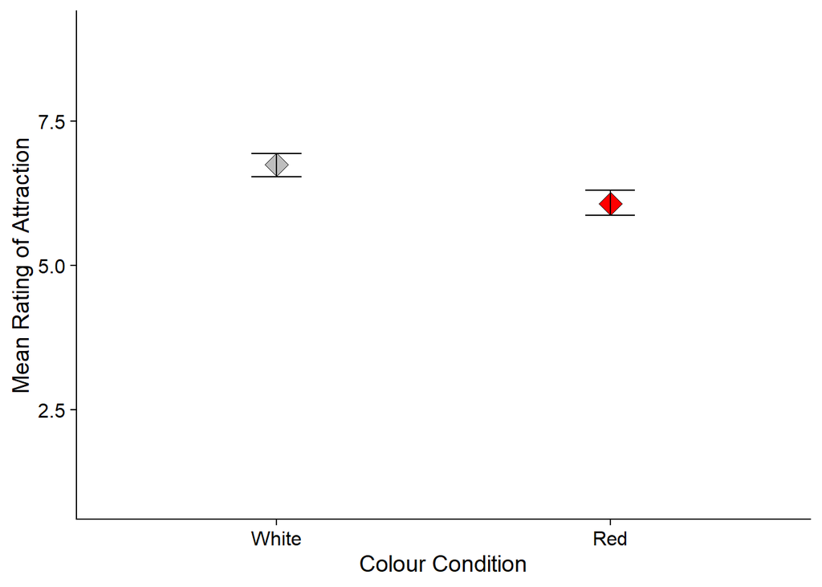

*Figure 1: Relationship between mean rating of perceived attraction and colour conditions, red and white. Standard errors are indicated by vertical lines.*

# Discussion

This experiment explored the influence of the colour red on the attraction rating of a man’s photograph. Analysis of the data showed an inverse effect on the predicted relationship, as red negatively influenced attraction ratings comapared to white. These findings refute the the ‘red effect’ (Elliot et al., 2010), where red was found to increase attraction scores. This suggests that Elliot’s findings may not be reliable, as we failed to replicate the results despite utilising the same experimental method. Although, it could be argued that the smaller sample size used here may have impacted the reliability of the results so a bigger sample size would be needed to test whether the red effect is truly significant. This replication challenges Colour-in-Context theory (Elliot & Maier, 2012) which explores red connotations to sex, dominance and wealth, linking to evolutionary drives of attraction as an explanation for the cultural symbolism of red and romance; yet this study shows that red is not always associated with attraction so other connotations may have influenced the decrease in attraction levels. It is plausible that women are less attracted to dominant masculinity nowadays, as females have more freedom to be independent compared to the past so these historical evolutionary influences are less potent.

In this study, level of attraction was measured thoroughly, assessed through 3 items which drew on objective and subjective opinions of the participants. The use of self-reported attraction shows high face validity as it’s the simpliest way to measure participant opinion on attraction, and mimicks conversations people may have in their personal lives. Furthermore, none of the participants correctly guessed the purpose of the experiment so we can conclude that colour influenced attraction ratings of participant without their awareness.

Some researchers claim methodological differences are to blame for the conflicting data (Lehmann et al., 2018), exhibiting the complexity of measuring attraction scientifically due to it’s subjective and individual nature. This meta-analysis also discusses differences in the shade of red used, suggesting a larger effect size occurred when an original red shade is used (Lehmann et al., 2018); it is important to note this may have influenced our results. Moreover, we cannot conclude that the colour white increases attraction as it was only used as a contrast to the red frame; white was chosen due to it’s unobtrusive nature, but further research is required to investigate whether white actually increases attraction compared to other colours. Other studies have investigated colour effects on attraction through manipulation in clothing (Beall & Tracy, 2013) or facial features (Jones et al., 2018; Stefan et al., 2018). Manipulations such as these may have better real-world applications as their findings could influence or explain current aesthetic cultural trends involving colour of clothing or make-up trends.

This study utilises only 1 caucasian male model, and participants from Western cultures. Some researchers have attempted to prove universality of the colour effect on attraction (Elliot et al., 2013; Jones et al., 2018), yet cross-cultural findings on this phenomena are not conclusive. Future research may decide to focus on using models of a variety of races, as well as conducting experiments with participants in other cultures to test whether the effect of colour on attraction can be generalised cross-culturally. This would make findings more representative and ensure any colour effects found are applicable in all contexts.

In summary, this study found that red in fact decreased attraction ratings refuting the ‘red effect’ previously suggested (Elliot et al., 2010). This adds to the contradictory findings in this research area(Peperkoorn et al., 2016; Berthold et al., 2017; Lehmann et al., 2018; Elliot et al., 2013), suggesting that it is a complex phenomena which may not be generalisable to all contexts. The difficulty of measuring the subjective position of attraction may be responsible for the differences in findings as well as the ways in which colour is manipulated. Research on the universality of colour-in-context theory is limited, so further research focused on cross-cultural aspects would be useful. Overall, this experiment provides important information regarding Elliot et al. (2010) findings, showing that they are not entirely reliable, therefore more evidence is required to reach a definitive conclusion on the significance of the ‘red effect’.

# References

Beall, A. T., & Tracy, J. L. (2013). Women Are More Likely to Wear Red or Pink at Peak Fertility. Psychological Science, 24(9), 1837–1841. https://doi.org/10.1177/0956797613476045

Berthold, A., Reese, G., & Martin, J. (2017). The effect of red color on perceived self-attractiveness. European Journal of Social Psychology, 47(5), 645–652. https://doi.org/10.1002/ejsp.2238

Stefan, S., Coetzee, N., & Coetzee, V. (2018). Facial Adiposity, Attractiveness, and Health: A Review. Frontiers in Psychology, 9. https://doi.org/10.3389/fpsyg.2018.02562

Elliot, A. J., & Maier, M. A. (2012). Chapter two—Color-in-Context Theory. In P. Devine & A. Plant (Eds.), Advances in Experimental Social Psychology (Vol. 45, pp. 61–125). Academic Press. https://doi.org/10.1016/B978-0-12-394286-9.00002-0

Elliot, A. J., Niesta Kayser, D., Greitemeyer, T., Lichtenfeld, S., Gramzow, R. H., Maier, M. A., & Liu, H. (2010). Red, rank, and romance in women viewing men. Journal of Experimental Psychology: General, 139(3), 399–417. https://doi.org/10.1037/a0019689

Elliot, A. J., Tracy, J. L., Pazda, A. D., & Beall, A. T. (2013). Red enhances women’s attractiveness to men: First evidence suggesting universality. Journal of Experimental Social Psychology, 49(1), 165–168. https://doi.org/10.1016/j.jesp.2012.07.017

Jones, B. C., Hahn, A. C., Fisher, C. I., Wang, H., Kandrik, M., Han, C., Fasolt, V., Morrison, D., Lee, A. J., Holzleitner, I. J., O’Shea, K. J., Roberts, S. C., Little, A. C., & DeBruine, L. M. (2018). No Compelling Evidence that Preferences for Facial Masculinity Track Changes in Women’s Hormonal Status: Psychological Science. https://doi.org/10.1177/0956797618760197

Lehmann, G. K., Elliot, A. J., & Calin-Jageman, R. J. (2018). Meta-Analysis of the Effect of Red on Perceived Attractiveness: Evolutionary Psychology. https://doi.org/10.1177/1474704918802412

Peperkoorn, L. S., Roberts, S. C., & Pollet, T. V. (2016). Revisiting the Red Effect on Attractiveness and Sexual Receptivity: No Effect of the Color Red on Human Mate Preferences. Evolutionary Psychology, 14(4), 1474704916673841. https://doi.org/10.1177/1474704916673841